# Pràctiques_analítiques

ANNA SERENA LATRE/XAVIER JORDÀ MURRIA

19 maig de 2019

# 1 Descàrrega de llibreries i base de dades.

## 1.1 Descàrrega de llibreries.

```r
# Packages download.
library(readr)
library(party)
library(car)
library(pscl)
library(ROCR)
library(kernlab)
library(circlize)
library(aod)
```

## 1.2 Descàrrega de datasets.

```r
# Databases download.
Train_T <- read_csv("C:/Users/ANNA/Desktop/Tipologia i cicle de vida de les dades/TipologiaPAC2/output_data/Train_T.csv")
Test_T <- read_csv("C:/Users/ANNA/Desktop/Tipologia i cicle de vida de les dades/TipologiaPAC2/output_data/Test_T.csv")
```

Per defecte els datasets amb les pràctiques d’integració i neteja guarden una nova variable amb la indexació dels registres que suprimirem en els dos conjunts Train_T i Test_T.

```r
# Test_T variable names.
names(Test_T)
```

```
## [1] "X1"       "Survived" "Pclass"   "Sex"      "Age"      "SibSp"
## [7] "Parch"    "Fare"     "Embarked"
```

Suprimim la variable X1 en el conjunt Test_T.

```r
# Deleting x1 variable.
Test_T <- subset(Test_T, select=c(2,3,4,5,6,7,8,9))
```

```r
# Train_T variables names.
names(Train_T)
```

```
## [1] "X1"       "Survived" "Pclass"   "Sex"      "Age"      "SibSp"
## [7] "Parch"    "Fare"     "Embarked"
```

Suprimim la variable X1 en el conjunt Train_T:

```r
# Deleting x1 variable.
Train_T <- subset(Train_T, select=c(2,3,4,5,6,7,8,9))
```

# 2 Analítica descriptiva:

Comentar que desestimem les tasques d’inferència estadística donat que les variables numèriques amb caràcter continu Age i Fare, com hem pogut comprovar en els fitxers Fitxer_Train.Rmd i Fitxer_Test.Rmd, no entren en la tipificació d’unes distribucions normals.

En una aproximació a les dades, ens servim dels arbres de decisió per a una classificació dels sucessos èxit i fracàs segons la rellevància de les variables, perquè aquest algorisme aporta una visualització de les dades en una comprensió ràpida en una fase descriptiva inicial.

## 2.1 Arbres de decisió i suport gràfic.

Ens cal una factorialització de les variables per tal que puguin interactuar en la regressió de l’arbre de decisió.

```r
# Categorical variables factorization.
Train_T$Survived <- as.factor(Train_T$Survived)
Train_T$Pclass <- as.factor(Train_T$Pclass)
Train_T$Sex <- as.factor(Train_T$Sex)
Train_T$SibSp <- as.factor(Train_T$SibSp)
Train_T$Parch <- as.factor(Train_T$Parch)
Train_T$Embarked <- as.factor(Train_T$Embarked)
```

En un principi apliquem l’algorisme d’arbres de decisió en totes les variables del dataset Train_T partint de la variable succés Survived.

```r
# Decision tree with all Train_T variables.
model_1 <- ctree(Survived~ ., data = Train_T)
model_1
```

```
##
##   Conditional inference tree with 7 terminal nodes
##
## Response:  Survived
## Inputs:  Pclass, Sex, Age, SibSp, Parch, Fare, Embarked
## Number of observations:  889
##
## 1) Sex == {male}; criterion = 1, statistic = 260.463
##   2) Pclass == {2, 3}; criterion = 1, statistic = 32.897
##     3) Age <= 9; criterion = 1, statistic = 20.633
##       4) SibSp == {3, 4, 5}; criterion = 0.999, statistic = 25.457
##         5)*  weights = 14
##       4) SibSp == {0, 1, 2}
##         6)*  weights = 16
##     3) Age > 9
##       7)*  weights = 425
##   2) Pclass == {1}
##     8)*  weights = 122
## 1) Sex == {female}
##   9) Pclass == {3}; criterion = 1, statistic = 80.602
##     10) Fare <= 23.25; criterion = 0.999, statistic = 14.348
##       11)*  weights = 117
##     10) Fare > 23.25
##       12)*  weights = 27
##   9) Pclass == {1, 2}
##     13)*  weights = 168
```

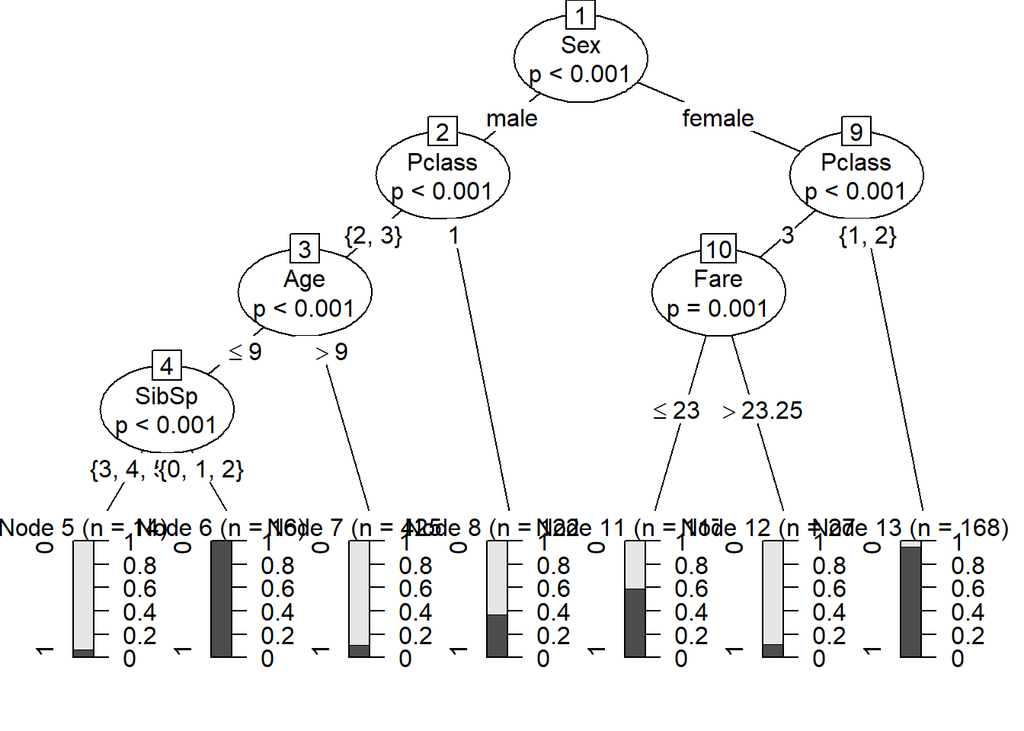

```r
plot(model_1)
```

L’arbre de decisió ens situa en primer lloc Sex com la variable amb més capacitat de segmentació partint de la variable Survived, en segon nivell situa la variable Pclass i en un tercer nivell situa la variable edat. Respectarem aquest ordre en l’anàlisi descriptiu posterior.

Procedim a una valoració de la variable sexe segons el succés: supervivent o bé ofegat.

```r
# Classifier Tree Model for Survived and Sex variables.
model_2 <- ctree(Survived~Sex, data = Train_T)
model_2
```

```
##
##   Conditional inference tree with 2 terminal nodes
##
## Response:  Survived
## Input:  Sex
## Number of observations:  889
##
## 1) Sex == {male}; criterion = 1, statistic = 260.463
##   2)*  weights = 577
## 1) Sex == {female}
##   3)*  weights = 312
```

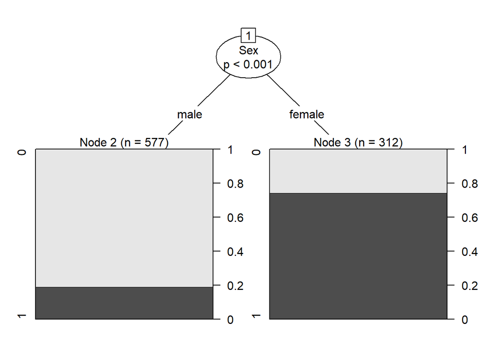

```r
plot(model_2)
```

L’arbre de decisió ens mostra clarament com el segment femení disposa d’un succés supervivent (nº 1) proper al 80%, mentre que en el sector masculí l’esdeveniment supervivent (nº 1) és un segment minoritari proper a un 20%.

Gràfic per a la visualització de les distribucions en les variables categòriques Survived i Sex.

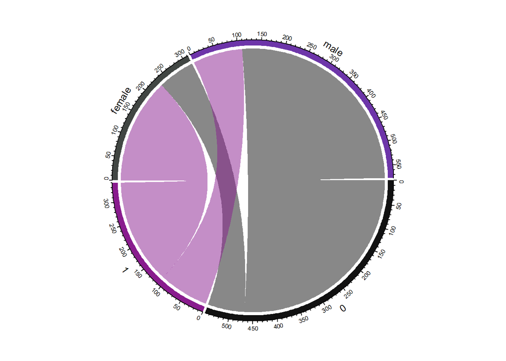

```r
# Circular plot for Survived and sex factor relationships.
donut <- data.frame(Train_T$Survived,Train_T$Sex)
donut<- with(donut, table(Train_T$Survived, Train_T$Sex))


# Make the circular plot
chordDiagram(as.data.frame(donut), transparency = 0.5)
```

Procedim a una valoració en segon lloc de la variable Pclass segons el succés: supervivent o bé ofegat.

```r
# Classifier Tree Model for Survived and Pclass variables.
model_3 <- ctree(Survived~Pclass, data = Train_T)
model_3
```

```
##
##   Conditional inference tree with 3 terminal nodes
##
## Response:  Survived
## Input:  Pclass
## Number of observations:  889
##
## 1) Pclass == {1, 2}; criterion = 1, statistic = 100.867
##   2) Pclass == {1}; criterion = 0.998, statistic = 9.397
##     3)*  weights = 214
##   2) Pclass == {2}
##     4)*  weights = 184
## 1) Pclass == {3}
##   5)*  weights = 491
```

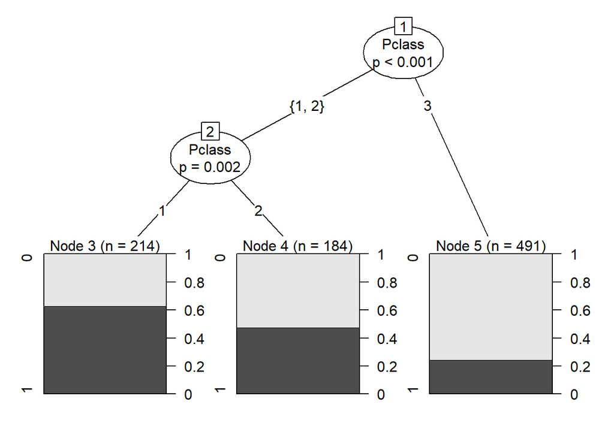

```r
plot(model_3)
```

En el gràfic observem com els passatgers de primera categoria en un total de 214 sobreviuen en poc més d’un 60%, mentre que els pasatgers de segona categoria (en un segment minoritari 184 passatgers) sobreviuen en un 50% i finalment el segment majoritari de tercera categoria, en 491 passatgers els supvervivents sumen poc més d’un 20%.

Gràfic per a la visualització de les distribucions en les variables categòriques Survived i Pclass.

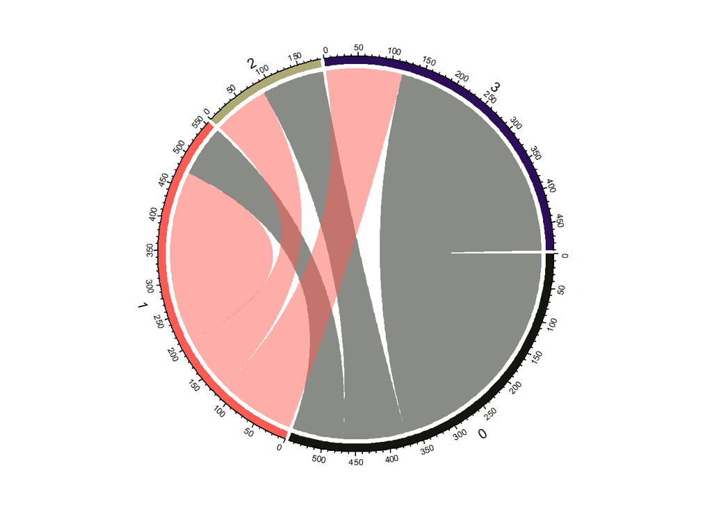

```r
# Circular plot for Survived and Pclass factor relationships.
donut <- data.frame(Train_T$Survived,Train_T$Pclass)
donut<- with(donut, table(Train_T$Survived, Train_T$Pclass))


# Make the circular plot
chordDiagram(as.data.frame(donut), transparency = 0.5)
```

Procedim a una valoració de la variable Age segons el succés: supervivent o bé ofegat.

```r
# Classifier Tree Model for Survived and Age variables.
model_2 <- ctree(Survived~Age, data = Train_T)
model_2
```

```
##
##   Conditional inference tree with 2 terminal nodes
##
## Response:  Survived
## Input:  Age
## Number of observations:  889
##
## 1) Age <= 6; criterion = 0.974, statistic = 4.952
##   2)*  weights = 47
## 1) Age > 6
##   3)*  weights = 842
```

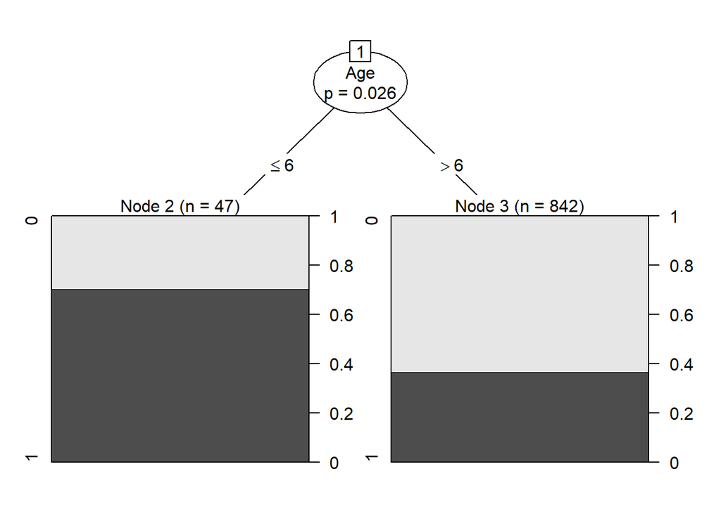

```r
plot(model_2)
```

En el gràfic observem com els infants de sis o menys anys, malgrat ser un segment minoritari i vulnerable sobreviuen en un 70% aproximadament i ens consta que entre els ofegats només hi havia una nena de primera classe.

Procedim a una valoració de la variable Age segons el succés Pclass: primera, segona i tercera categoria.

```r
# Classifier Tree Model for Pclass and Age variables.
model_3 <- ctree(Pclass~Age, data = Train_T)
model_3
```

```
##
##   Conditional inference tree with 3 terminal nodes
##
## Response:  Pclass
## Input:  Age
## Number of observations:  889
##
## 1) Age <= 34.5; criterion = 1, statistic = 98.211
##   2)*  weights = 656
## 1) Age > 34.5
##   3) Age <= 45.5; criterion = 0.981, statistic = 7.883
##     4)*  weights = 133
##   3) Age > 45.5
##     5)*  weights = 100
```

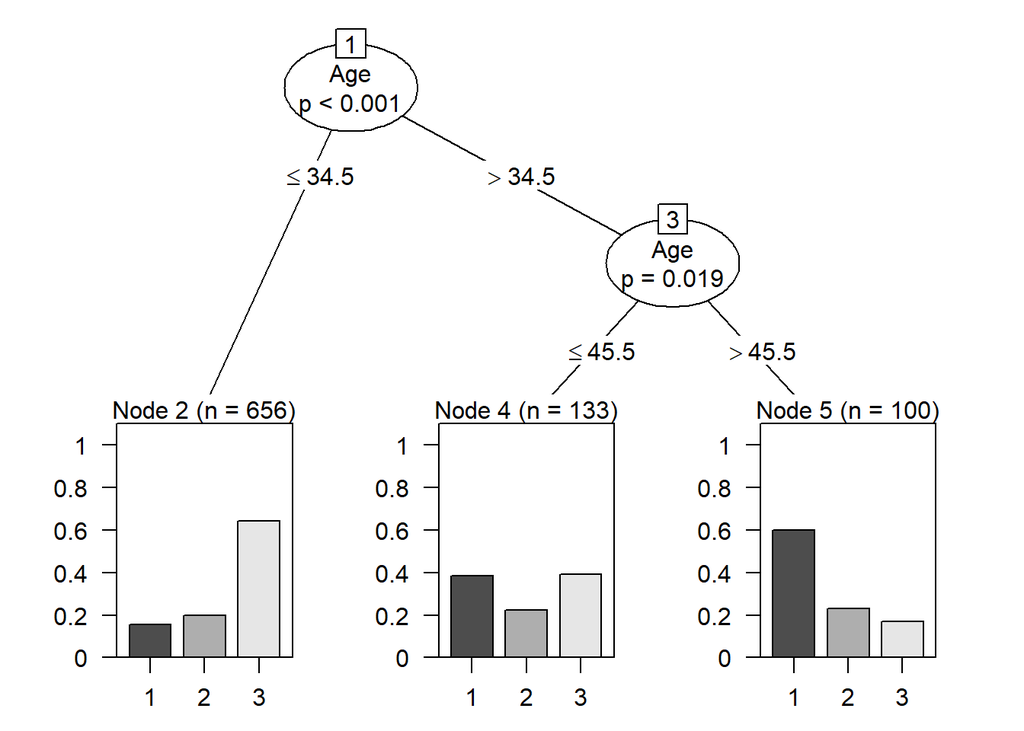

```r
plot(model_3)
```

En general observem com el segment més nombrós són les persones menors de 35 anys, amb un total de 656 individus, els quals es concentren en la tercera categoria i per tant constatem que varen morir moltes persones joves.

Les conclusions a es quals arribem són:

```
  El perfil majoritari de les persones ofegades és el d'una persona jove       que viatja en tercera categoria.
  El perfil majoritari de les persones supervivents és el d'una dona que       viatja en primera categoria.

  Les consignes de salvament que donaven preferència als infants i les        dones en els bots de salvament es varen complir amb més o menys             rigorositat.
```

# 3 Models de regressió, classificació i predicció:

## 3.1 Model de regressió logística.

L’algorisme de regressió logística no ens accepta la variable Parch en les proves Train&Test i per tant la suprimim.

```r
names(Train_T)
```

```
## [1] "Survived" "Pclass"   "Sex"      "Age"      "SibSp"    "Parch"
## [7] "Fare"     "Embarked"
```

```r
names(Test_T)
```

```
## [1] "Survived" "Pclass"   "Sex"      "Age"      "SibSp"    "Parch"
## [7] "Fare"     "Embarked"
```

```r
# Deleting Parch variable.
Train_T <- subset(Train_T, select=c(1,2,3,4,5,7,8))
names(Train_T)
```

```
## [1] "Survived" "Pclass"   "Sex"      "Age"      "SibSp"    "Fare"
## [7] "Embarked"
```

```r
# Deleting Parch variable.
Test_T <- subset(Test_T, select=c(1,2,3,4,5,7,8))
names(Test_T)
```

```
## [1] "Survived" "Pclass"   "Sex"      "Age"      "SibSp"    "Fare"
## [7] "Embarked"
```

Model de regressió logística per al conjunt de dades Train_T, amb la variable dependent Survived.

```r
# Logistic regression model.
reg.model =glm(Survived ~., family = binomial(link = 'logit'), data = Train_T)
summary(reg.model)
```

```
##
## Call:
## glm(formula = Survived ~ ., family = binomial(link = "logit"),
##     data = Train_T)
##
## Deviance Residuals:
##     Min       1Q   Median       3Q      Max
## -2.7993  -0.6002  -0.4125   0.6083   2.4862
##
## Coefficients:
##               Estimate Std. Error z value Pr(>|z|)
## (Intercept)   3.925681   0.477894   8.215  < 2e-16 ***
## Pclass2      -0.983963   0.298553  -3.296 0.000982 ***
## Pclass3      -2.126366   0.295880  -7.187 6.64e-13 ***
## Sexmale      -2.645883   0.197588 -13.391  < 2e-16 ***
## Age          -0.040708   0.008081  -5.038 4.72e-07 ***
## SibSp1        0.140612   0.212147   0.663 0.507456
## SibSp2       -0.184671   0.521856  -0.354 0.723434
## SibSp3       -2.009086   0.712034  -2.822 0.004778 **
## SibSp4       -1.589729   0.736990  -2.157 0.031001 *
## SibSp5      -15.921629 960.694512  -0.017 0.986777
## SibSp8      -15.796329 758.696121  -0.021 0.983389
## Fare          0.001942   0.002309   0.841 0.400443
## EmbarkedQ     0.048253   0.381772   0.126 0.899422
## EmbarkedS    -0.381258   0.242040  -1.575 0.115213
## ---
## Signif. codes:  0 '***' 0.001 '**' 0.01 '*' 0.05 '.' 0.1 ' ' 1
##
## (Dispersion parameter for binomial family taken to be 1)
##
##     Null deviance: 1182.8  on 888  degrees of freedom
## Residual deviance:  773.7  on 875  degrees of freedom
## AIC: 801.7
##
## Number of Fisher Scoring iterations: 15
```

En el model de regressió logística observem com les variables que d’entrada eren més rellevants en les tasques d’agrupament i classificació con Sex, Pclass i Age, obtenen un p-valor molt proper a zero i inferior al nivell de significació 0.5, i per tant són estadísticament significatives.

```r
confint(reg.model)
```

[output not shown]

[output cut: 100 more lines]

[output not shown]

```
##                    2.5 %       97.5 %
## (Intercept)  3.006246133  4.882704277
## Pclass2     -1.572838384 -0.400508579
## Pclass3     -2.711515092 -1.548921024
## Sexmale     -3.041828593 -2.266341300
## Age         -0.056869256 -0.025148335
## SibSp1      -0.277871185  0.554824957
## SibSp2      -1.218351721  0.833360172
## SibSp3      -3.532823848 -0.691168339
## SibSp4      -3.204182656 -0.240146910
## SibSp5                NA 83.721028974
## SibSp8                NA 52.142019137
## Fare        -0.002401649  0.006893904
## EmbarkedQ   -0.703356137  0.795323294
## EmbarkedS   -0.854805427  0.095311787
```

```r
exp(cbind(OR = coef(reg.model), confint(reg.model)))
```

[output not shown]

[output cut: 100 more lines]

[output not shown]

```
##                       OR       2.5 %       97.5 %
## (Intercept) 5.068758e+01 20.21138648 1.319871e+02
## Pclass2     3.738269e-01  0.20745551 6.699792e-01
## Pclass3     1.192699e-01  0.06643607 2.124771e-01
## Sexmale     7.094268e-02  0.04774750 1.036909e-01
## Age         9.601098e-01  0.94471758 9.751653e-01
## SibSp1      1.150978e+00  0.75739438 1.741636e+00
## SibSp2      8.313779e-01  0.29571719 2.301038e+00
## SibSp3      1.341112e-01  0.02922228 5.009904e-01
## SibSp4      2.039808e-01  0.04059207 7.865123e-01
## SibSp5      1.217094e-07          NA 2.288658e+36
## SibSp8      1.379563e-07          NA 4.415615e+22
## Fare        1.001944e+00  0.99760123 1.006918e+00
## EmbarkedQ   1.049436e+00  0.49492149 2.215157e+00
## EmbarkedS   6.830015e-01  0.42536595 1.100002e+00
```

Inferència ANOVA per el model de regressió logística per a l’analítica de les desviacions:

```r
# ANOVA test for the regression model.
anova(reg.model, Test="Chisq")
```

```
## Analysis of Deviance Table
##
## Model: binomial, link: logit
##
## Response: Survived
##
## Terms added sequentially (first to last)
##
##
##          Df Deviance Resid. Df Resid. Dev
## NULL                       888    1182.82
## Pclass    2  101.571       886    1081.25
## Sex       1  254.743       885     826.50
## Age       1   21.828       884     804.68
## SibSp     6   26.080       878     778.60
## Fare      1    1.249       877     777.35
## Embarked  2    3.649       875     773.70
```

Dades complementàries del model :

```r
pR2(reg.model)
```

```
##          llh      llhNull           G2     McFadden         r2ML
## -386.8487212 -591.4088880  409.1203336    0.3458862    0.3688444
##         r2CU
##    0.5013817
```

## 3.2 Prova train&test per al model de regressió logística.

Factorialitzem les variables en el conjunt test per tal que siguin vàlides per els models algorísmics:

```r
# Categorical variables factorization.

Test_T$Pclass <- as.factor(Test_T$Pclass)
Test_T$Sex <- as.factor(Test_T$Sex)
Test_T$SibSp <- as.factor(Test_T$SibSp)
Test_T$Embarked <- as.factor(Test_T$Embarked)
```

Prediccions del model de regressió logística:

```r
# Linear Regression model predictment.
titanic_predict <- predict(reg.model, newdata = subset(Test_T,select = c(1:7),  type='response'))
head(titanic_predict)
```

```
##          1          2          3          4          5          6
## -2.1875245 -0.3409958 -2.1609708 -2.3101103  0.6869617 -1.7798192
```

```r
titanic_predict <- ifelse(titanic_predict > 0.5, 1,0)
head(titanic_predict)
```

```
## 1 2 3 4 5 6
## 0 0 0 0 1 0
```

```r
# Logistic regression true and false matrix.
table(titanic_predict, Test_T$Survived)
```

```
##
## titanic_predict   0   1
##               0 262  30
##               1   4 122
```

En la matriu de confussió observem els encerts del model de regresssió logística i la component erràtica en relació als supervivents i ofegats. En aquest sentit classifica erròniament 4 ofegats que eren supervivents i altrament classifica erròniament 30 supervivents que són ofegats.

El model de regressió logística mostra una accuracy molt bona en una capacitat de predicció d’un 91’86%.

```r
# Logistic regression model error.
misClassificError = mean(titanic_predict != Test_T$Survived)
# Logistic regression accuracy.
print(paste('Accuracy', 1 - misClassificError))
```

```
## [1] "Accuracy 0.91866028708134"
```

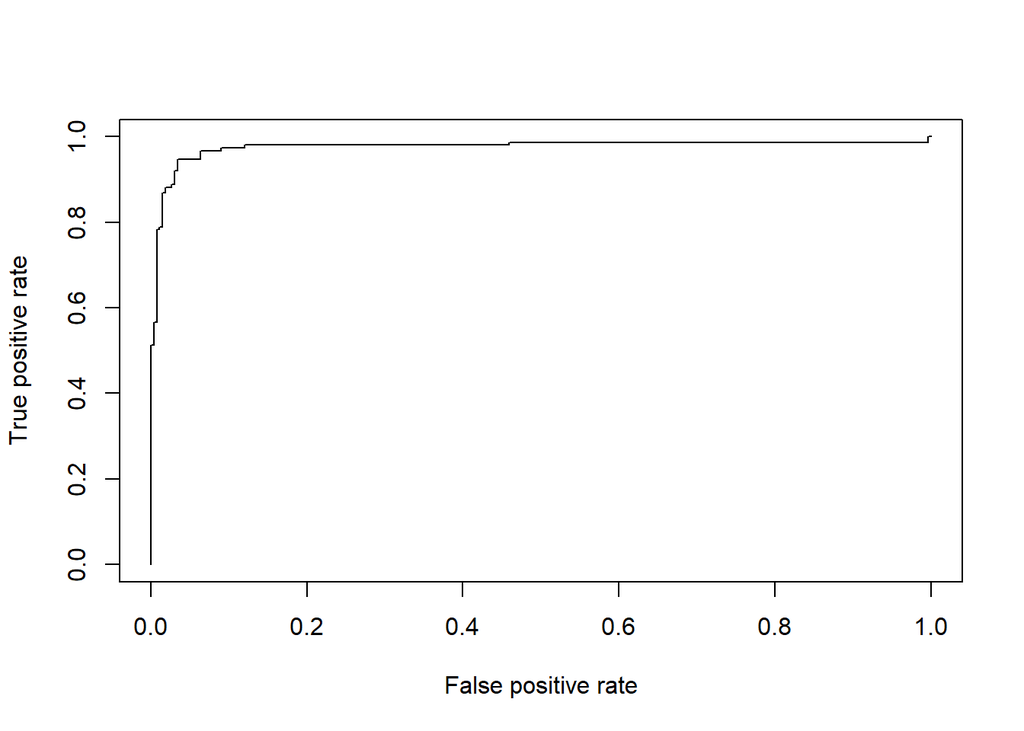

```r
# ROC curve for positivie and false TRUE.

p<- predict(reg.model, newdata = Test_T, type='response')
pr <- prediction(p, Test_T$Survived)
prf <- performance(pr, measure = "tpr", x.measure = "fpr")
plot(prf)
```

La corba Roc ens corrobora la capacitat del model proper a l’angle 1 de l’esquerra per el qual optmiza l’encert en la ràtio dels vertaders positius i minimitza l’error en la ràtio dels Falsos positius.

```r
# AUC performance.
auc <- performance(pr, measure="auc")
str(auc)
```

```
## Formal class 'performance' [package "ROCR"] with 6 slots
##   ..@ x.name      : chr "None"
##   ..@ y.name      : chr "Area under the ROC curve"
##   ..@ alpha.name  : chr "none"
##   ..@ x.values    : list()
##   ..@ y.values    :List of 1
##   .. ..$ : num 0.976
##   ..@ alpha.values: list()
```

El punt optimitzador en la corva ROC del model és de 97’58 %.

```r
# AUC value.
auc= auc@y.values[[1]]
auc
```

```
## [1] 0.975836
```

El model de regressió logística és un bon model predictor.

## 3.3 Model SVM Suported Vectorial Machine.

```r
# Databases download.
Train_T <- read_csv("C:/Users/ANNA/Desktop/Tipologia i cicle de vida de les dades/TipologiaPAC2/output_data/Train_T.csv")
Test_T <- read_csv("C:/Users/ANNA/Desktop/Tipologia i cicle de vida de les dades/TipologiaPAC2/output_data/Test_T.csv")
# Deleting x1 variable.
Test_T <- subset(Test_T, select=c(2,3,4,5,6,7,8))
Train_T <- subset(Train_T, select=c(2,3,4,5,6,7,8))
```

Procedim a la construcció d’un model SVM Suport Vectorial Machine en el conjunt Train_T.

```r
# SVM model construction.

svm.model <- ksvm(Survived ~ ., data = Train_T, kernel ='vanilladot')
```

Resultats del model SVM en el conjunt Train_T:

```r
# SVM parameter model and results.
svm.model
```

```
## Support Vector Machine object of class "ksvm"
##
## SV type: eps-svr  (regression)
##  parameter : epsilon = 0.1  cost C = 1
##
## Linear (vanilla) kernel function.
##
## Number of Support Vectors : 410
##
## Objective Function Value : -353.5994
## Training error : 0.825748
```

## 3.4 Prova train&test per a l’algorisme SVM.

Proves de la capacitat predictiva del model SVM:

```r
# SVM predictments.
svm.predict <- predict(svm.model, Test_T[,1:7])
head(svm.predict)
```

```
##         [,1]
## 1 0.04851173
## 2 0.95100536
## 3 0.04836949
## 4 0.04857404
## 5 0.95113985
## 6 0.04867879
```

```r
svm.predict = ifelse(svm.predict > 0.5, 1, 0)
```

Mariu de confussió del model SVM:

```r
# SVM true and false matrix.
table(svm.predict, Test_T$Survived)
```

```
##
## svm.predict   0   1
##           0 266   0
##           1   0 152
```

Observem com el model procedeix amb una classificació òptima sense component erràtica.

```r
# SVM error model.
misClassifiError = mean(svm.predict != Test_T$Survived)
# SVM accuracy model.
print(paste('Accuracy', 1 - misClassifiError))
```

```
## [1] "Accuracy 1"
```

L’accuracy del model SVM és d’una capacitat predicitva òptima d’un 100%.

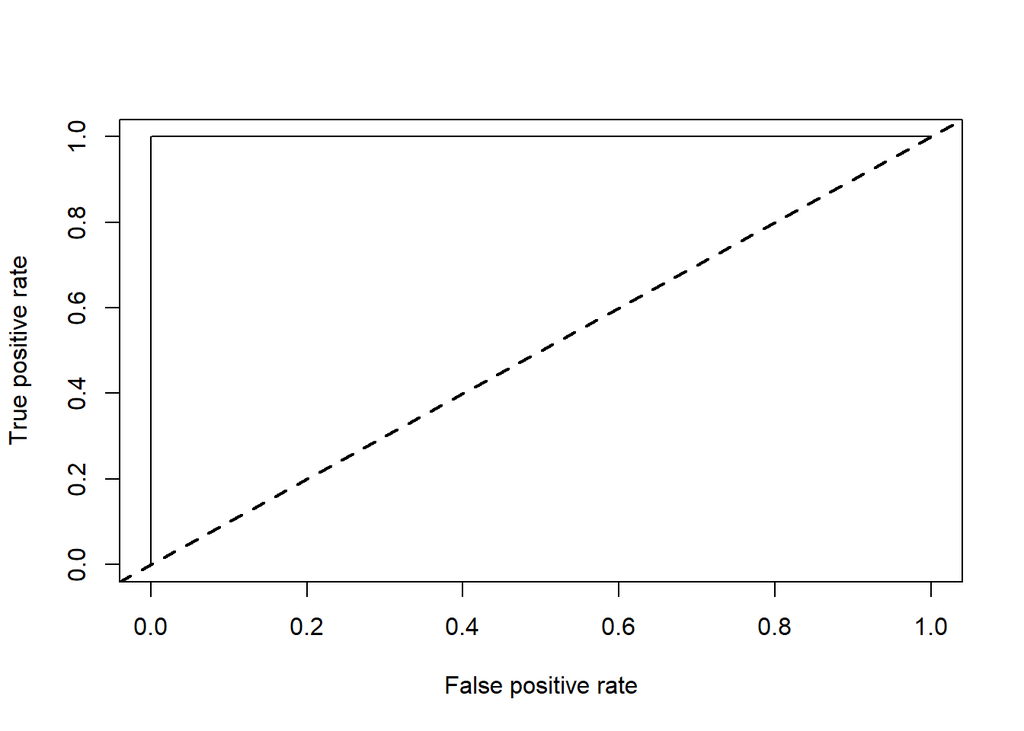

```r
# Plotting SVM true and false positives.
p = predict(svm.model, newdata = subset(Test_T, select=c(1:7)), type='response')
pr = prediction(p, Test_T$Survived)
prf = performance(pr, measure = 'tpr', x.measure ='fpr')
plot(prf)
abline(0,1, lwd =2, lty =2)
```

En la corba ROC observem com el model es troba en l’angle 1 de l’esquerre optimitzant la capacitat predictiva i minimitzant l’error a 0.

```r
# SVM AUC performance.
auc = performance(pr, measure = 'auc')
str(auc)
```

```
## Formal class 'performance' [package "ROCR"] with 6 slots
##   ..@ x.name      : chr "None"
##   ..@ y.name      : chr "Area under the ROC curve"
##   ..@ alpha.name  : chr "none"
##   ..@ x.values    : list()
##   ..@ y.values    :List of 1
##   .. ..$ : num 1
##   ..@ alpha.values: list()
```

El punt AUC òptim del model SVM és 1.

```r
# SVM auc value.
auc <- auc@y.values[[1]]
auc
```

```
## [1] 1
```

# 4 Referències

*Stackoverflow (2019)* Solucions data mining i analítiques. Disseny del lloc web/logo©2019 Stack Exchange Inc: contribucions d’usuaris llicenciats en cc by-sa 3.0.

Disponible a: https://es.stackoverflow.com/

*Statmethods.net (2019)* Quick R – by DataCamp. Kaabacoff, R.I.; ‘ANOVA’ . Copyright © 2012 Robert I. Kabacoff, Ph.D.

Disponible a: https://www.statmethods.net/stats/anova.html

*Rpubs.com (2019)* Brought to you by RStudio. Li, E.C.; ‘Titanic Survival Analysis Using Logisic Regression’. Easy web publishing. RStudio™ Support.

Disponible a: https://rstudio-pubs-static.s3.amazonaws.com/283447_fd922429e1f0415c89b93b6da6dc1ccc.html